# **Replicating Adams et al. (2023)**

## Table 4.1 (stargazer)

```r
# With clustered ses
stargazer(
  type = "html", table.4.1,
  add.lines = list(c("Country-Year Fixed Effects?", "Yes"),
                   c("Out-Party Fixed Effects?", "Yes"),
                   c("Country-Level Clustered ses?", "Yes")),
  se = starprep(table.4.1,
    clusters = dta_early_small$country
  ),
  keep = c("to_pfeml", "rile_distance_s", "prior_coalition",
           "prior_opposition"),
  report = "vc*sp"
)
```

|  | *Dependent variable:* |
| --- | --- |
|  | party_like |
| to_pfeml | 1.134** |
|  | (0.548) |
|  | p = 0.039 |
| rile_distance_s | -0.697*** |
|  | (0.114) |
|  | p = 0.000 |
| prior_coalition | 0.879*** |
|  | (0.281) |
|  | p = 0.002 |
| prior_opposition | 0.371** |
|  | (0.170) |
|  | p = 0.029 |
| Country-Year Fixed Effects? | Yes |
| Out-Party Fixed Effects? | Yes |
| Country-Level Clustered ses? | Yes |
| Observations | 848 |
| R<sup>2</sup> | 0.365 |
| Adjusted R<sup>2</sup> | 0.332 |
| Residual Std. Error | 1.197 (df = 805) |
| F Statistic | 11.017*** (df = 42; 805) |
| *Note:* | p<0.1; p<0.05; p<0.01 |

```r
cat("### Table 4.1")
```

### Table 4.1

```r
table.4.1 |>
  report_table() |>
  filter(!grepl("countryyear|Intercept", Parameter)) |>
  nice_table(highlight = TRUE, short = TRUE,
             col.format.custom = 2, format.custom = "format3")
```

| Parameter | b | CI | t | df | p | b* | Std_Coefficient_CI_low | Std_Coefficient_CI_high | Fit | 95% CI |
| --- | --- | --- | --- | --- | --- | --- | --- | --- | --- | --- |
| to pfeml | 1.134 | 0.95 | 3.06 | 805 | .002** | 0.12 | 0.04 | 0.19 |  | [0.41, 1.86] |
| rile distance s | -0.697 | 0.95 | -14.83 | 805 | < .001*** | -0.47 | -0.53 | -0.40 |  | [-0.79, -0.61] |
| prior coalition | 0.879 | 0.95 | 5.69 | 805 | < .001*** | 0.19 | 0.12 | 0.25 |  | [0.58, 1.18] |
| prior opposition | 0.371 | 0.95 | 3.91 | 805 | < .001*** | 0.12 | 0.06 | 0.19 |  | [0.18, 0.56] |
|  | NA |  |  |  |  |  |  |  |  |  |
| AIC | NA |  |  |  |  |  |  |  | 2,754.91 |  |
| AICc | NA |  |  |  |  |  |  |  | 2,759.84 |  |
| BIC | NA |  |  |  |  |  |  |  | 2,963.60 |  |
| R2 | NA |  |  |  |  |  |  |  | 0.36 |  |
| R2 (adj.) | NA |  |  |  |  |  |  |  | 0.33 |  |
| Sigma | NA |  |  |  |  |  |  |  | 1.20 |  |

## Table 4.2 (stargazer)

```r
# With clustered ses
stargazer(
  type = "html", table.4.2,
  add.lines = list(c("Country-Year Fixed Effects?", "Yes"),
                   c("Out-Party Fixed Effects?", "Yes"),
                   c("Country-Level Clustered SEs?", "Yes")),
  se = starprep(table.4.2,
    clusters = dta_late_small$country
  ),
  keep = c("to_pfeml", "rile_distance_s", "prior_coalition",
           "prior_opposition"),
  report = "vc*sp"
)
```

|  | *Dependent variable:* |
| --- | --- |
|  | party_like |
| to_pfeml | 2.063*** |
|  | (0.688) |
|  | p = 0.003 |
| rile_distance_s | -0.505*** |
|  | (0.133) |
|  | p = 0.0002 |
| prior_coalition | 0.966*** |
|  | (0.290) |
|  | p = 0.001 |
| prior_opposition | 0.366* |
|  | (0.191) |
|  | p = 0.056 |
| Country-Year Fixed Effects? | Yes |
| Out-Party Fixed Effects? | Yes |
| Country-Level Clustered SEs? | Yes |
| Observations | 994 |
| R<sup>2</sup> | 0.328 |
| Adjusted R<sup>2</sup> | 0.296 |
| Residual Std. Error | 1.322 (df = 948) |
| F Statistic | 10.278*** (df = 45; 948) |
| *Note:* | p<0.1; p<0.05; p<0.01 |

```r
cat("### Table 4.2")
```

### Table 4.2

```r
table.4.2 |>
  report_table() |>
  filter(!grepl("countryyear|Intercept", Parameter)) |>
  nice_table(highlight = TRUE, short = TRUE,
             col.format.custom = 2, format.custom = "format3")
```

| Parameter | b | CI | t | df | p | b* | Std_Coefficient_CI_low | Std_Coefficient_CI_high | Fit | 95% CI |
| --- | --- | --- | --- | --- | --- | --- | --- | --- | --- | --- |
| to pfeml | 2.063 | 0.95 | 6.59 | 948 | < .001*** | 0.21 | 0.15 | 0.28 |  | [1.45, 2.68] |
| rile distance s | -0.505 | 0.95 | -10.13 | 948 | < .001*** | -0.32 | -0.38 | -0.26 |  | [-0.60, -0.41] |
| prior coalition | 0.966 | 0.95 | 6.63 | 948 | < .001*** | 0.19 | 0.14 | 0.25 |  | [0.68, 1.25] |
| prior opposition | 0.366 | 0.95 | 3.71 | 948 | < .001*** | 0.11 | 0.05 | 0.17 |  | [0.17, 0.56] |
|  | NA |  |  |  |  |  |  |  |  |  |
| AIC | NA |  |  |  |  |  |  |  | 3,422.65 |  |
| AICc | NA |  |  |  |  |  |  |  | 3,427.42 |  |
| BIC | NA |  |  |  |  |  |  |  | 3,653.03 |  |
| R2 | NA |  |  |  |  |  |  |  | 0.33 |  |
| R2 (adj.) | NA |  |  |  |  |  |  |  | 0.30 |  |
| Sigma | NA |  |  |  |  |  |  |  | 1.32 |  |

```r
############################################
############ CREATING TABLE S5 #############
############################################

load("_data/dyadic_data_1-4-22.Rdata")

dta <- updated_data |>
  mutate(countryyear = paste(country, year, sep = "")) |>
  # creating the country-year fixed effects
  select(
    year, country, rile_distance_s, prior_coalition, prior_opposition,
    econ_distance_s, society_distance_s, party_dislike, party_like, countryyear,
    to_pfeml, from_pfeml, diff_pfeml, to_prior_seats
  ) |>
  na.omit()

# Remove small parties, with fewer than 4 seats
dta_small <- dta |> filter(to_prior_seats >= 4)

table.S5.1 <- lm(party_like ~ to_pfeml + from_pfeml + diff_pfeml +
                   as.factor(countryyear), data = dta_small)
table.S5.2 <- lm(party_like ~ to_pfeml + from_pfeml + diff_pfeml +
                   rile_distance_s + prior_coalition + prior_opposition +
                   as.factor(countryyear), data = dta_small)
```

## Table 5

```r
# With clustered ses
stargazer(
  type = "html", table.S5.1, table.S5.2,
  add.lines = list(c("Country-Year Fixed Effects?", "Yes"),
                   c("Country-Level Clustered SEs?", "Yes")),
  se = starprep(table.S5.1, table.S5.2,
    clusters = dta_small$country
  ),
  keep = c(
    "to_pfeml", "from_pfeml", "diff_pfeml", "rile_distance_s",
    "prior_coalition", "prior_opposition",
    "econ_distance_s", "society_distance_s"
  ),
  report = "vc*sp"
)
```

|  | *Dependent variable:* |  |
| --- | --- | --- |
|  | party_like |  |
|  | (1) | (2) |
| to_pfeml | 2.079*** | 1.838*** |
|  | (0.473) | (0.554) |
|  | p = 0.00002 | p = 0.001 |
| from_pfeml | 0.773*** | 0.569*** |
|  | (0.227) | (0.215) |
|  | p = 0.001 | p = 0.009 |
| diff_pfeml | -1.621** | -1.026** |
|  | (0.664) | (0.519) |
|  | p = 0.015 | p = 0.048 |
| rile_distance_s |  | -0.596*** |
|  |  | (0.076) |
|  |  | p = 0.000 |
| prior_coalition |  | 0.891*** |
|  |  | (0.264) |
|  |  | p = 0.001 |
| prior_opposition |  | 0.384*** |
|  |  | (0.104) |
|  |  | p = 0.0003 |
| Country-Year Fixed Effects? | Yes |  |
| Country-Level Clustered SEs? | Yes |  |
| Observations | 1,593 | 1,593 |
| R<sup>2</sup> | 0.216 | 0.359 |
| Adjusted R<sup>2</sup> | 0.174 | 0.323 |
| Residual Std. Error | 1.379 (df = 1510) | 1.248 (df = 1507) |
| F Statistic | 5.076*** (df = 82; 1510) | 9.924*** (df = 85; 1507) |
| *Note:* | p<0.1; p<0.05; p<0.01 |  |

```r
cat("### Table 5.1")
```

### Table 5.1

```r
table.S5.1 |>
  report_table() |>
  filter(!grepl("countryyear|Intercept", Parameter)) |>
  nice_table(highlight = TRUE, short = TRUE,
             col.format.custom = 2, format.custom = "format3")
```

| Parameter | b | CI | t | df | p | b* | Std_Coefficient_CI_low | Std_Coefficient_CI_high | Fit | 95% CI |
| --- | --- | --- | --- | --- | --- | --- | --- | --- | --- | --- |
| to pfeml | 2.079 | 0.95 | 7.45 | 1,510 | < .001*** | 0.22 | 0.16 | 0.28 |  | [1.53, 2.63] |
| from pfeml | 0.773 | 0.95 | 3.47 | 1,510 | .001*** | 0.10 | 0.04 | 0.15 |  | [0.34, 1.21] |
| diff pfeml | -1.621 | 0.95 | -5.99 | 1,510 | < .001*** | -0.16 | -0.21 | -0.10 |  | [-2.15, -1.09] |
|  | NA |  |  |  |  |  |  |  |  |  |
| AIC | NA |  |  |  |  |  |  |  | 5,626.55 |  |
| AICc | NA |  |  |  |  |  |  |  | 5,636.01 |  |
| BIC | NA |  |  |  |  |  |  |  | 6,077.91 |  |
| R2 | NA |  |  |  |  |  |  |  | 0.22 |  |
| R2 (adj.) | NA |  |  |  |  |  |  |  | 0.17 |  |
| Sigma | NA |  |  |  |  |  |  |  | 1.38 |  |

```r
cat("### Table 5.2")
```

### Table 5.2

```r
table.S5.2 |>
  report_table() |>
  filter(!grepl("countryyear|Intercept", Parameter)) |>
  nice_table(highlight = TRUE, short = TRUE,
             col.format.custom = 2, format.custom = "format3")
```

| Parameter | b | CI | t | df | p | b* | Std_Coefficient_CI_low | Std_Coefficient_CI_high | Fit | 95% CI |
| --- | --- | --- | --- | --- | --- | --- | --- | --- | --- | --- |
| to pfeml | 1.838 | 0.95 | 7.24 | 1,507 | < .001*** | 0.19 | 0.14 | 0.25 |  | [1.34, 2.34] |
| from pfeml | 0.569 | 0.95 | 2.81 | 1,507 | .005** | 0.07 | 0.02 | 0.12 |  | [0.17, 0.97] |
| diff pfeml | -1.026 | 0.95 | -4.09 | 1,507 | < .001*** | -0.10 | -0.15 | -0.05 |  | [-1.52, -0.53] |
| rile distance s | -0.596 | 0.95 | -15.78 | 1,507 | < .001*** | -0.38 | -0.43 | -0.34 |  | [-0.67, -0.52] |
| prior coalition | 0.891 | 0.95 | 8.16 | 1,507 | < .001*** | 0.19 | 0.15 | 0.24 |  | [0.68, 1.11] |
| prior opposition | 0.384 | 0.95 | 5.19 | 1,507 | < .001*** | 0.12 | 0.08 | 0.17 |  | [0.24, 0.53] |
|  | NA |  |  |  |  |  |  |  |  |  |
| AIC | NA |  |  |  |  |  |  |  | 5,312.28 |  |
| AICc | NA |  |  |  |  |  |  |  | 5,322.45 |  |
| BIC | NA |  |  |  |  |  |  |  | 5,779.76 |  |
| R2 | NA |  |  |  |  |  |  |  | 0.36 |  |
| R2 (adj.) | NA |  |  |  |  |  |  |  | 0.32 |  |
| Sigma | NA |  |  |  |  |  |  |  | 1.25 |  |

```r
############################################
############ CREATING FIG. S1 #############
############################################

# All values of Out-Party % women

plot_1 <- dta |>
  distinct(to_pfeml) |>
  mutate(
    from_pfeml = mean(dta$from_pfeml, na.rm = T) + sd(dta$from_pfeml, na.rm = T),
    # All 1 Sd above mean of in-party % women
    diff_pfeml = abs(to_pfeml - from_pfeml),
    # Create difference between in-and out-party women
    # Select other values (mean RILE distance, opposition together,
    # France 2012 country year)
    rile_distance_s = mean(dta$rile_distance_s, na.rm = T),
    prior_coalition = 0,
    prior_opposition = 1,
    countryyear = "France2012",
    to_mp_number = "31320",
    group = "above_mean"
  )

# All values of Out-Party % women
plot_2 <- dta |>
  distinct(to_pfeml) |>
  mutate(
    from_pfeml = mean(dta$from_pfeml, na.rm = T) - sd(dta$from_pfeml, na.rm = T),
    # All 1 Sd below mean of In-party % women
    diff_pfeml = abs(to_pfeml - from_pfeml),
    # Create difference between in-and out-party women
    # Select other values (opposition together, France 2012 country year)
    rile_distance_s = mean(dta$rile_distance_s, na.rm = T),
    prior_coalition = 0,
    prior_opposition = 1,
    countryyear = "France2012",
    to_mp_number = "31320",
    group = "below_mean"
  )

plot_dta <- bind_rows(plot_1, plot_2)

## Plot based on table.S5.2

figureS1.data <- as.data.frame(predict(table.S5.2, newdata = plot_dta,
                                       interval = "confidence"))

plot_dta <- plot_dta |>
  mutate(
    fit = figureS1.data$fit,
    lwr = figureS1.data$lwr,
    upr = figureS1.data$upr
  )
```

## Figure S1

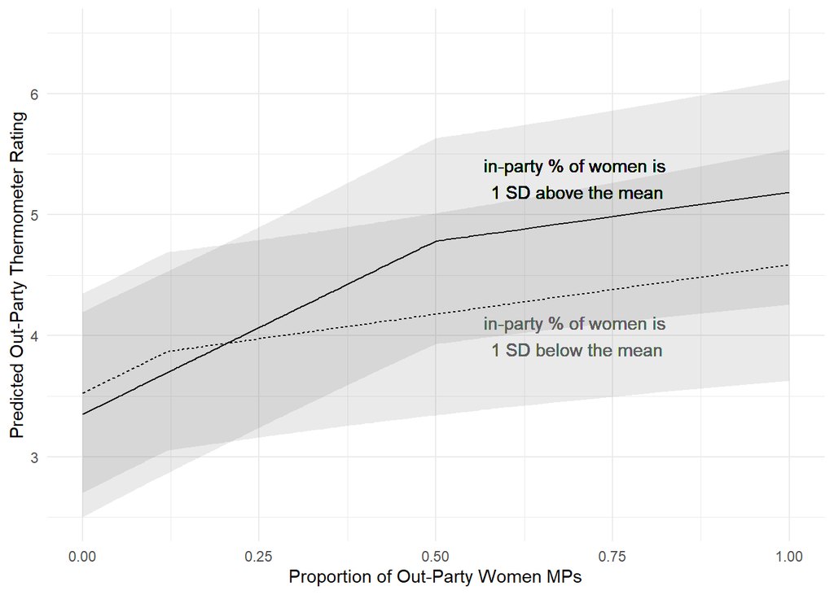

```r
ggplot(plot_dta, aes(x = to_pfeml, y = fit, lty = group)) +
  geom_line() +
  geom_ribbon(
    aes(
      x = to_pfeml, y = fit, ymin = lwr,
      ymax = upr
    ),
    lwd = 1 / 2, alpha = 0.1
  ) +
  theme_minimal() +
  theme(plot.title = element_text(size = 12)) +
  ylab("Predicted Out-Party Thermometer Rating") +
  xlab("Proportion of Out-Party Women MPs") +
  theme(legend.position = "none") +
  geom_text(x = 0.70, y = 5.3,
            label = "in-party % of women is \n1 SD above the mean") +
  geom_text(x = 0.70, y = 4.0,
            label = "in-party % of women is \n1 SD below the mean",
            color = "grey37") +
  ylim(c(2.5, 6.5))
```

```r
ggsave("_graphs/figS1.pdf", width = 12, height = 10)

############################################
############ CREATING TABLE S6 #############
############################################

## Read in data
load("_data/dyadic_data_1-4-22.Rdata")

dta <- updated_data |>
  mutate(countryyear = paste(country, year, sep = "")) |>
  # creating the country-year fixed effects
  select(
    year, country, rile_distance_s, prior_coalition,
    prior_opposition, econ_distance_s, society_distance_s,
    party_dislike, party_like, countryyear, to_pfeml,
    from_rile, to_rile, logDM, to_left_bloc, to_prior_seats
  ) |>
  na.omit()

dta_small <- dta |> filter(to_prior_seats >= 4)

table.S6.1 <- lm(party_like ~ to_pfeml + rile_distance_s + logDM +
                   prior_coalition + prior_opposition + as.factor(year),
                 data = dta_small)
table.S6.2 <- lm(party_like ~ to_pfeml * logDM + rile_distance_s +
                   prior_coalition + prior_opposition + as.factor(year),
                 data = dta_small)
table.S6.3 <- lm(party_like ~ to_pfeml * logDM + rile_distance_s * logDM +
                   prior_coalition * logDM + prior_opposition * logDM +
                   as.factor(year), data = dta_small)
```

## Table S6

```r
stargazer(
  type = "html", table.S6.1, table.S6.2, table.S6.3,
  add.lines = list(c("Country-Year Fixed Effects?", "Yes"),
                   c("Country-Level Clustered SEs?", "Yes")),
  se = starprep(table.S6.1, table.S6.2, table.S6.3,
    clusters = dta_small$country
  ),
  keep = c(
    "to_pfeml", "rile_distance_s", "logDM", "prior_coalition",
    "prior_opposition", "econ_distance_s", "society_distance_s"
  ),
  report = "vc*sp"
)
```

|  | *Dependent variable:* |  |  |
| --- | --- | --- | --- |
|  | party_like |  |  |
|  | (1) | (2) | (3) |
| to_pfeml | 1.752*** | 2.119*** | 2.136*** |
|  | (0.416) | (0.813) | (0.818) |
|  | p = 0.00003 | p = 0.010 | p = 0.010 |
| rile_distance_s | -0.526*** | -0.530*** | -0.430*** |
|  | (0.076) | (0.075) | (0.150) |
|  | p = 0.000 | p = 0.000 | p = 0.005 |
| logDM | 0.067 | 0.102* | 0.130*** |
|  | (0.041) | (0.059) | (0.050) |
|  | p = 0.103 | p = 0.084 | p = 0.010 |
| prior_coalition | 1.057*** | 1.060*** | 1.205** |
|  | (0.203) | (0.204) | (0.482) |
|  | p = 0.00000 | p = 0.00000 | p = 0.013 |
| prior_opposition | 0.339*** | 0.336*** | 0.451** |
|  | (0.115) | (0.114) | (0.226) |
|  | p = 0.004 | p = 0.004 | p = 0.047 |
| to_pfeml:logDM |  | -0.126 | -0.148 |
|  |  | (0.223) | (0.230) |
|  |  | p = 0.573 | p = 0.521 |
| logDM:rile_distance_s |  |  | -0.038 |
|  |  |  | (0.059) |
|  |  |  | p = 0.522 |
| logDM:prior_coalition |  |  | -0.054 |
|  |  |  | (0.121) |
|  |  |  | p = 0.655 |
| logDM:prior_opposition |  |  | -0.039 |
|  |  |  | (0.063) |
|  |  |  | p = 0.533 |
| Country-Year Fixed Effects? | Yes |  |  |
| Country-Level Clustered SEs? | Yes |  |  |
| Observations | 1,842 | 1,842 | 1,842 |
| R<sup>2</sup> | 0.262 | 0.263 | 0.265 |
| Adjusted R<sup>2</sup> | 0.252 | 0.252 | 0.252 |
| Residual Std. Error | 1.320 (df = 1815) | 1.320 (df = 1814) | 1.319 (df = 1811) |
| F Statistic | 24.796*** (df = 26; 1815) | 23.916*** (df = 27; 1814) | 21.713*** (df = 30; 1811) |
| *Note:* | p<0.1; p<0.05; p<0.01 |  |  |

```r
cat("### Table S6.1")
```

### Table S6.1

```r
table.S6.1 |>
  report_table() |>
  filter(!grepl("year|Intercept", Parameter)) |>
  nice_table(highlight = TRUE, short = TRUE,
             col.format.custom = 2, format.custom = "format3")
```

| Parameter | b | CI | t | df | p | b* | Std_Coefficient_CI_low | Std_Coefficient_CI_high | Fit | 95% CI |
| --- | --- | --- | --- | --- | --- | --- | --- | --- | --- | --- |
| to pfeml | 1.752 | 0.95 | 8.09 | 1,815 | < .001*** | 0.18 | 0.14 | 0.23 |  | [1.33, 2.18] |
| rile distance s | -0.526 | 0.95 | -16.44 | 1,815 | < .001*** | -0.34 | -0.38 | -0.30 |  | [-0.59, -0.46] |
| logDM | 0.067 | 0.95 | 3.05 | 1,815 | .002** | 0.08 | 0.03 | 0.13 |  | [0.02, 0.11] |
| prior coalition | 1.057 | 0.95 | 10.01 | 1,815 | < .001*** | 0.22 | 0.17 | 0.26 |  | [0.85, 1.26] |
| prior opposition | 0.339 | 0.95 | 5.05 | 1,815 | < .001*** | 0.11 | 0.07 | 0.15 |  | [0.21, 0.47] |
|  | NA |  |  |  |  | 0.24 | -0.14 | 0.62 |  |  |
|  | NA |  |  |  |  | -0.59 | -1.03 | -0.15 |  |  |
|  | NA |  |  |  |  | -0.19 | -0.51 | 0.13 |  |  |
|  | NA |  |  |  |  | 0.11 | -0.17 | 0.39 |  |  |
|  | NA |  |  |  |  | -0.08 | -0.36 | 0.20 |  |  |
|  | NA |  |  |  |  | -0.00 | -0.33 | 0.32 |  |  |
|  | NA |  |  |  |  | 0.05 | -0.24 | 0.34 |  |  |
|  | NA |  |  |  |  | -0.05 | -0.31 | 0.20 |  |  |
|  | NA |  |  |  |  | 0.09 | -0.16 | 0.35 |  |  |
|  | NA |  |  |  |  | -0.64 | -0.93 | -0.36 |  |  |
|  | NA |  |  |  |  | -0.11 | -0.40 | 0.18 |  |  |
|  | NA |  |  |  |  | 0.09 | -0.20 | 0.38 |  |  |
|  | NA |  |  |  |  | -0.07 | -0.33 | 0.20 |  |  |
|  | NA |  |  |  |  | -0.49 | -0.83 | -0.15 |  |  |
|  | NA |  |  |  |  | -0.15 | -0.43 | 0.13 |  |  |
|  | NA |  |  |  |  | 0.07 | -0.26 | 0.40 |  |  |
|  | NA |  |  |  |  | -0.33 | -0.62 | -0.03 |  |  |
|  | NA |  |  |  |  | -0.29 | -0.72 | 0.13 |  |  |
|  | NA |  |  |  |  | -0.09 | -0.36 | 0.18 |  |  |
|  | NA |  |  |  |  | 0.01 | -0.30 | 0.31 |  |  |
|  | NA |  |  |  |  | -0.05 | -0.39 | 0.29 |  |  |
|  | NA |  |  |  |  |  |  |  |  |  |
| AIC | NA |  |  |  |  |  |  |  | 6,277.83 |  |
| AICc | NA |  |  |  |  |  |  |  | 6,278.72 |  |
| BIC | NA |  |  |  |  |  |  |  | 6,432.35 |  |
| R2 | NA |  |  |  |  |  |  |  | 0.26 |  |
| R2 (adj.) | NA |  |  |  |  |  |  |  | 0.25 |  |
| Sigma | NA |  |  |  |  |  |  |  | 1.32 |  |

```r
cat("### Table S6.2")
```

### Table S6.2

```r
table.S6.2 |>
  report_table() |>
  filter(!grepl("year|Intercept", Parameter)) |>
  nice_table(highlight = TRUE, short = TRUE,
             col.format.custom = 2, format.custom = "format3")
```

| Parameter | b | CI | t | df | p | b* | Std_Coefficient_CI_low | Std_Coefficient_CI_high | Fit | 95% CI |
| --- | --- | --- | --- | --- | --- | --- | --- | --- | --- | --- |
| to pfeml | 2.119 | 0.95 | 5.03 | 1,814 | < .001*** | 0.18 | 0.14 | 0.23 |  | [1.29, 2.95] |
| logDM | 0.102 | 0.95 | 2.50 | 1,814 | .013* | 0.07 | 0.02 | 0.12 |  | [0.02, 0.18] |
| rile distance s | -0.530 | 0.95 | -16.46 | 1,814 | < .001*** | -0.35 | -0.39 | -0.30 |  | [-0.59, -0.47] |
| prior coalition | 1.060 | 0.95 | 10.03 | 1,814 | < .001*** | 0.22 | 0.18 | 0.26 |  | [0.85, 1.27] |
| prior opposition | 0.336 | 0.95 | 5.02 | 1,814 | < .001*** | 0.11 | 0.07 | 0.15 |  | [0.20, 0.47] |
| to pfeml × logDM | -0.126 | 0.95 | -1.02 | 1,814 | .309 | -0.02 | -0.07 | 0.02 |  | [-0.37, 0.12] |
|  | NA |  |  |  |  | 0.24 | -0.13 | 0.62 |  |  |
|  | NA |  |  |  |  | -0.59 | -1.03 | -0.15 |  |  |
|  | NA |  |  |  |  | -0.17 | -0.49 | 0.15 |  |  |
|  | NA |  |  |  |  | 0.11 | -0.17 | 0.40 |  |  |
|  | NA |  |  |  |  | -0.09 | -0.37 | 0.19 |  |  |
|  | NA |  |  |  |  | -0.00 | -0.33 | 0.33 |  |  |
|  | NA |  |  |  |  | 0.05 | -0.24 | 0.34 |  |  |
|  | NA |  |  |  |  | -0.04 | -0.30 | 0.21 |  |  |
|  | NA |  |  |  |  | 0.09 | -0.16 | 0.35 |  |  |
|  | NA |  |  |  |  | -0.64 | -0.93 | -0.36 |  |  |
|  | NA |  |  |  |  | -0.09 | -0.39 | 0.20 |  |  |
|  | NA |  |  |  |  | 0.08 | -0.21 | 0.37 |  |  |
|  | NA |  |  |  |  | -0.07 | -0.33 | 0.20 |  |  |
|  | NA |  |  |  |  | -0.48 | -0.82 | -0.14 |  |  |
|  | NA |  |  |  |  | -0.14 | -0.42 | 0.14 |  |  |
|  | NA |  |  |  |  | 0.09 | -0.24 | 0.42 |  |  |
|  | NA |  |  |  |  | -0.32 | -0.61 | -0.02 |  |  |
|  | NA |  |  |  |  | -0.28 | -0.70 | 0.15 |  |  |
|  | NA |  |  |  |  | -0.08 | -0.35 | 0.18 |  |  |
|  | NA |  |  |  |  | 0.00 | -0.30 | 0.31 |  |  |
|  | NA |  |  |  |  | -0.04 | -0.38 | 0.30 |  |  |
|  | NA |  |  |  |  |  |  |  |  |  |
| AIC | NA |  |  |  |  |  |  |  | 6,278.78 |  |
| AICc | NA |  |  |  |  |  |  |  | 6,279.74 |  |
| BIC | NA |  |  |  |  |  |  |  | 6,438.81 |  |
| R2 | NA |  |  |  |  |  |  |  | 0.26 |  |
| R2 (adj.) | NA |  |  |  |  |  |  |  | 0.25 |  |
| Sigma | NA |  |  |  |  |  |  |  | 1.32 |  |

```r
cat("### Table S6.3")
```

### Table S6.3

```r
table.S6.3 |>
  report_table() |>
  filter(!grepl("year|Intercept", Parameter)) |>
  nice_table(highlight = TRUE, short = TRUE,
             col.format.custom = 2, format.custom = "format3")
```

| Parameter | b | CI | t | df | p | b* | Std_Coefficient_CI_low | Std_Coefficient_CI_high | Fit | 95% CI |
| --- | --- | --- | --- | --- | --- | --- | --- | --- | --- | --- |
| to pfeml | 2.136 | 0.95 | 5.07 | 1,811 | < .001*** | 0.18 | 0.13 | 0.22 |  | [1.31, 2.96] |
| logDM | 0.130 | 0.95 | 2.93 | 1,811 | .003** | 0.07 | 0.02 | 0.12 |  | [0.04, 0.22] |
| rile distance s | -0.430 | 0.95 | -7.02 | 1,811 | < .001*** | -0.35 | -0.39 | -0.31 |  | [-0.55, -0.31] |
| prior coalition | 1.205 | 0.95 | 5.38 | 1,811 | < .001*** | 0.22 | 0.17 | 0.26 |  | [0.77, 1.64] |
| prior opposition | 0.451 | 0.95 | 3.59 | 1,811 | < .001*** | 0.11 | 0.07 | 0.15 |  | [0.20, 0.70] |
| to pfeml × logDM | -0.148 | 0.95 | -1.19 | 1,811 | .233 | -0.03 | -0.07 | 0.02 |  | [-0.39, 0.10] |
| logDM × rile distance s | -0.038 | 0.95 | -1.91 | 1,811 | .056 | -0.04 | -0.09 | 0.00 |  | [-0.08, 0.00] |
| logDM × prior coalition | -0.054 | 0.95 | -0.82 | 1,811 | .412 | -0.02 | -0.07 | 0.03 |  | [-0.18, 0.08] |
| logDM × prior opposition | -0.039 | 0.95 | -1.03 | 1,811 | .303 | -0.02 | -0.06 | 0.02 |  | [-0.11, 0.04] |
|  | NA |  |  |  |  | 0.22 | -0.16 | 0.60 |  |  |
|  | NA |  |  |  |  | -0.60 | -1.04 | -0.16 |  |  |
|  | NA |  |  |  |  | -0.19 | -0.51 | 0.13 |  |  |
|  | NA |  |  |  |  | 0.10 | -0.19 | 0.38 |  |  |
|  | NA |  |  |  |  | -0.10 | -0.38 | 0.18 |  |  |
|  | NA |  |  |  |  | -0.01 | -0.34 | 0.31 |  |  |
|  | NA |  |  |  |  | 0.04 | -0.25 | 0.33 |  |  |
|  | NA |  |  |  |  | -0.05 | -0.31 | 0.20 |  |  |
|  | NA |  |  |  |  | 0.08 | -0.17 | 0.34 |  |  |
|  | NA |  |  |  |  | -0.64 | -0.92 | -0.36 |  |  |
|  | NA |  |  |  |  | -0.09 | -0.39 | 0.20 |  |  |
|  | NA |  |  |  |  | 0.07 | -0.22 | 0.35 |  |  |
|  | NA |  |  |  |  | -0.08 | -0.34 | 0.19 |  |  |
|  | NA |  |  |  |  | -0.52 | -0.86 | -0.18 |  |  |
|  | NA |  |  |  |  | -0.17 | -0.45 | 0.12 |  |  |
|  | NA |  |  |  |  | 0.05 | -0.28 | 0.38 |  |  |
|  | NA |  |  |  |  | -0.33 | -0.62 | -0.03 |  |  |
|  | NA |  |  |  |  | -0.27 | -0.70 | 0.15 |  |  |
|  | NA |  |  |  |  | -0.10 | -0.37 | 0.17 |  |  |
|  | NA |  |  |  |  | -0.00 | -0.30 | 0.30 |  |  |
|  | NA |  |  |  |  | -0.04 | -0.38 | 0.30 |  |  |
|  | NA |  |  |  |  |  |  |  |  |  |
| AIC | NA |  |  |  |  |  |  |  | 6,279.73 |  |
| AICc | NA |  |  |  |  |  |  |  | 6,280.90 |  |
| BIC | NA |  |  |  |  |  |  |  | 6,456.33 |  |
| R2 | NA |  |  |  |  |  |  |  | 0.26 |  |
| R2 (adj.) | NA |  |  |  |  |  |  |  | 0.25 |  |
| Sigma | NA |  |  |  |  |  |  |  | 1.32 |  |

```r
############################################
############ CREATING TABLE S7 #############
############################################

# Out party % women, non-clustered SEs
load("_data/dyadic_data_1-4-22.Rdata")

dta <- updated_data |>
  mutate(cntryyr = paste(country, year, sep = "")) |>
  # creating the country-year fixed effects
  select(
    year, country, rile_distance_s, prior_coalition,
    prior_opposition, econ_distance_s, society_distance_s,
    party_dislike, party_like, cntryyr, to_pfeml, to_prior_seats
  ) |>
  na.omit() |>
  mutate(to_pfeml2 = to_pfeml^2) |>
  # Creating squared term for out-party % women
  filter(to_prior_seats >= 4)

table.S7.1 <- lm(party_like ~ to_pfeml + to_pfeml2 +
                   as.factor(cntryyr), data = dta)
table.S7.2 <- lm(party_like ~ to_pfeml + to_pfeml2 + rile_distance_s +
                   prior_coalition + prior_opposition + as.factor(cntryyr),
                 data = dta)
```

## Table S7

```r
# With clustered ses
stargazer(
  type = "html", table.S7.1, table.S7.2,
  add.lines = list(c("Country-Year Fixed Effects?", "Yes"),
                   c("Country-Level Clustered SEs?", "Yes")),
  se = starprep(table.S7.1, table.S7.2,
    clusters = dta$country
  ),
  keep = c(
    "to_pfeml", "to_pfeml2", "rile_distance_s", "prior_coalition",
    "prior_opposition", "econ_distance_s", "society_distance_s"
  ),
  report = "vc*sp"
)
```

|  | *Dependent variable:* |  |
| --- | --- | --- |
|  | party_like |  |
|  | (1) | (2) |
| to_pfeml | 4.403*** | 4.513*** |
|  | (1.235) | (1.382) |
|  | p = 0.0004 | p = 0.002 |
| to_pfeml2 | -3.705*** | -4.106*** |
|  | (1.421) | (1.511) |
|  | p = 0.010 | p = 0.007 |
| rile_distance_s |  | -0.600*** |
|  |  | (0.092) |
|  |  | p = 0.000 |
| prior_coalition |  | 0.927*** |
|  |  | (0.247) |
|  |  | p = 0.0002 |
| prior_opposition |  | 0.385*** |
|  |  | (0.104) |
|  |  | p = 0.0003 |
| Country-Year Fixed Effects? | Yes |  |
| Country-Level Clustered SEs? | Yes |  |
| Observations | 1,842 | 1,842 |
| R<sup>2</sup> | 0.196 | 0.346 |
| Adjusted R<sup>2</sup> | 0.159 | 0.315 |
| Residual Std. Error | 1.399 (df = 1759) | 1.263 (df = 1756) |
| F Statistic | 5.242*** (df = 82; 1759) | 10.947*** (df = 85; 1756) |
| *Note:* | p<0.1; p<0.05; p<0.01 |  |

```r
cat("### Table S7.1")
```

### Table S7.1

```r
table.S7.1 |>
  report_table() |>
  filter(!grepl("cntryyr|Intercept", Parameter)) |>
  nice_table(highlight = TRUE, short = TRUE,
             col.format.custom = 2, format.custom = "format3")
```

| Parameter | b | CI | t | df | p | b* | Std_Coefficient_CI_low | Std_Coefficient_CI_high | Fit | 95% CI |
| --- | --- | --- | --- | --- | --- | --- | --- | --- | --- | --- |
| to pfeml | 4.403 | 0.95 | 5.57 | 1,759 | < .001*** | 0.46 | 0.30 | 0.62 |  | [2.85, 5.95] |
| to pfeml2 | -3.705 | 0.95 | -3.37 | 1,759 | .001*** | -0.26 | -0.41 | -0.11 |  | [-5.86, -1.55] |
|  | NA |  |  |  |  |  |  |  |  |  |
| AIC | NA |  |  |  |  |  |  |  | 6,546.98 |  |
| AICc | NA |  |  |  |  |  |  |  | 6,555.11 |  |
| BIC | NA |  |  |  |  |  |  |  | 7,010.55 |  |
| R2 | NA |  |  |  |  |  |  |  | 0.20 |  |
| R2 (adj.) | NA |  |  |  |  |  |  |  | 0.16 |  |
| Sigma | NA |  |  |  |  |  |  |  | 1.40 |  |

```r
cat("### Table S7.2")
```

### Table S7.2

```r
table.S7.2 |>
  report_table() |>
  filter(!grepl("cntryyr|Intercept", Parameter)) |>
  nice_table(highlight = TRUE, short = TRUE,
             col.format.custom = 2, format.custom = "format3")
```

| Parameter | b | CI | t | df | p | b* | Std_Coefficient_CI_low | Std_Coefficient_CI_high | Fit | 95% CI |
| --- | --- | --- | --- | --- | --- | --- | --- | --- | --- | --- |
| to pfeml | 4.513 | 0.95 | 6.31 | 1,756 | < .001*** | 0.47 | 0.32 | 0.62 |  | [3.11, 5.92] |
| to pfeml2 | -4.106 | 0.95 | -4.13 | 1,756 | < .001*** | -0.29 | -0.43 | -0.15 |  | [-6.06, -2.16] |
| rile distance s | -0.600 | 0.95 | -17.46 | 1,756 | < .001*** | -0.39 | -0.43 | -0.35 |  | [-0.67, -0.53] |
| prior coalition | 0.927 | 0.95 | 8.76 | 1,756 | < .001*** | 0.19 | 0.15 | 0.23 |  | [0.72, 1.13] |
| prior opposition | 0.385 | 0.95 | 5.62 | 1,756 | < .001*** | 0.12 | 0.08 | 0.17 |  | [0.25, 0.52] |
|  | NA |  |  |  |  |  |  |  |  |  |
| AIC | NA |  |  |  |  |  |  |  | 6,172.48 |  |
| AICc | NA |  |  |  |  |  |  |  | 6,181.21 |  |
| BIC | NA |  |  |  |  |  |  |  | 6,652.60 |  |
| R2 | NA |  |  |  |  |  |  |  | 0.35 |  |
| R2 (adj.) | NA |  |  |  |  |  |  |  | 0.31 |  |
| Sigma | NA |  |  |  |  |  |  |  | 1.26 |  |

```r
############################################
############ CREATING FIG. S2 #############
############################################

## Create Plot Data

# All values of Out-Party % women

plot_S2 <- dta |>
  distinct(to_pfeml) |>
  mutate(
    to_pfeml2 = to_pfeml^2, # Create difference between in-and out-party women
    ## Select other values (mean RILE distance, opposition together,
    # France 2012 country year)
    rile_distance_s = mean(dta$rile_distance_s, na.rm = T),
    prior_coalition = 0,
    prior_opposition = 1,
    cntryyr = "France2012",
    to_mp_number = "31320"
  )

figureS2.data <- data.frame(predict(table.S7.2, newdata = plot_S2,
                                    interval = "confidence"))

plot_S2 <- plot_S2 |>
  mutate(
    fit = figureS2.data$fit,
    lwr = figureS2.data$lwr,
    upr = figureS2.data$upr
  )
```

## Figure S2

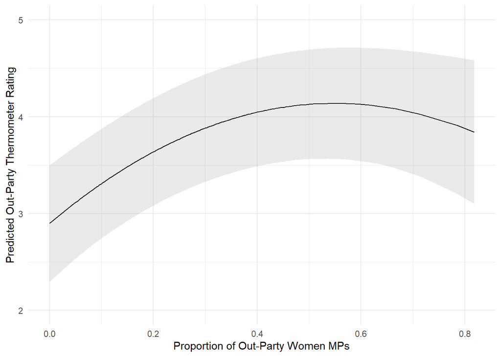

```r
ggplot(plot_S2, aes(x = to_pfeml, y = fit)) +
  geom_line() +
  geom_ribbon(
    aes(
      x = to_pfeml, y = fit, ymin = lwr,
      ymax = upr
    ),
    lwd = 1 / 2, alpha = 0.1
  ) +
  theme_minimal() +
  theme(plot.title = element_text(size = 12)) +
  ylab("Predicted Out-Party Thermometer Rating") +
  xlab("Proportion of Out-Party Women MPs") +
  ylim(c(2, 5))
```

```r
ggsave("_graphs/figS2.pdf", width = 12, height = 10)

############################################
############ CREATING TABLE S8 #############
############################################

# Women-led parties
load("_data/dyadic_data_1-4-22.Rdata")

dta_womenlead <- updated_data |>
  filter(to_femaleleader == 1) |>
  mutate(countryyear = paste(country, year, sep = "")) |>
  # creating the country-year fixed effects
  select(
    year, country, rile_distance_s, prior_coalition,
    prior_opposition, econ_distance_s, society_distance_s,
    party_dislike, party_like, countryyear, to_pfeml, to_prior_seats
  ) |>
  na.omit() |>
  filter(to_prior_seats >= 4)

table.S8A1 <- lm(party_like ~ to_pfeml + as.factor(countryyear),
                 data = dta_womenlead)
table.S8A2 <- lm(party_like ~ to_pfeml + rile_distance_s + prior_coalition +
                   prior_opposition + as.factor(countryyear),
                 data = dta_womenlead)
```

## Table S8A

```r
# With clustered SEs
stargazer(
  type = "html", table.S8A1, table.S8A2,
  add.lines = list(c("Country-Year Fixed Effects?", "Yes"),
                   c("Country-Level Clustered SEs?", "Yes")),
  se = starprep(table.S8A1, table.S8A2,
    clusters = dta_womenlead$country
  ),
  keep = c(
    "to_pfeml", "rile_distance_s", "prior_coalition", "prior_opposition",
    "econ_distance_s", "society_distance_s"
  ),
  report = "vc*sp"
)
```

|  | *Dependent variable:* |  |
| --- | --- | --- |
|  | party_like |  |
|  | (1) | (2) |
| to_pfeml | 0.918 | 0.390 |
|  | (0.852) | (0.801) |
|  | p = 0.282 | p = 0.627 |
| rile_distance_s |  | -0.821*** |
|  |  | (0.148) |
|  |  | p = 0.00000 |
| prior_coalition |  | 0.824*** |
|  |  | (0.236) |
|  |  | p = 0.0005 |
| prior_opposition |  | 0.399* |
|  |  | (0.225) |
|  |  | p = 0.077 |
| Country-Year Fixed Effects? | Yes |  |
| Country-Level Clustered SEs? | Yes |  |
| Observations | 479 | 479 |
| R<sup>2</sup> | 0.221 | 0.455 |
| Adjusted R<sup>2</sup> | 0.132 | 0.389 |
| Residual Std. Error | 1.312 (df = 429) | 1.101 (df = 426) |
| F Statistic | 2.477*** (df = 49; 429) | 6.844*** (df = 52; 426) |
| *Note:* | p<0.1; p<0.05; p<0.01 |  |

```r
cat("### Table S8A1")
```

### Table S8A1

```r
table.S8A1 |>
  report_table() |>
  filter(!grepl("countryyear|Intercept", Parameter)) |>
  nice_table(highlight = TRUE, short = TRUE,
             col.format.custom = 2, format.custom = "format3")
```

| Parameter | b | CI | t | df | p | b* | Std_Coefficient_CI_low | Std_Coefficient_CI_high | Fit | 95% CI |
| --- | --- | --- | --- | --- | --- | --- | --- | --- | --- | --- |
| to pfeml | 0.918 | 0.95 | 1.71 | 429 | .088 | 0.10 | -0.01 | 0.21 |  | [-0.14, 1.97] |
|  | NA |  |  |  |  |  |  |  |  |  |
| AIC | NA |  |  |  |  |  |  |  | 1,668.88 |  |
| AICc | NA |  |  |  |  |  |  |  | 1,681.30 |  |
| BIC | NA |  |  |  |  |  |  |  | 1,881.64 |  |
| R2 | NA |  |  |  |  |  |  |  | 0.22 |  |
| R2 (adj.) | NA |  |  |  |  |  |  |  | 0.13 |  |
| Sigma | NA |  |  |  |  |  |  |  | 1.31 |  |

```r
cat("### Table S8A2")
```

### Table S8A2

```r
table.S8A2 |>
  report_table() |>
  filter(!grepl("countryyear|Intercept", Parameter)) |>
  nice_table(highlight = TRUE, short = TRUE,
             col.format.custom = 2, format.custom = "format3")
```

| Parameter | b | CI | t | df | p | b* | Std_Coefficient_CI_low | Std_Coefficient_CI_high | Fit | 95% CI |
| --- | --- | --- | --- | --- | --- | --- | --- | --- | --- | --- |
| to pfeml | 0.390 | 0.95 | 0.86 | 426 | .391 | 0.04 | -0.05 | 0.14 |  | [-0.50, 1.28] |
| rile distance s | -0.821 | 0.95 | -12.63 | 426 | < .001*** | -0.54 | -0.63 | -0.46 |  | [-0.95, -0.69] |
| prior coalition | 0.824 | 0.95 | 4.37 | 426 | < .001*** | 0.18 | 0.10 | 0.25 |  | [0.45, 1.19] |
| prior opposition | 0.399 | 0.95 | 3.23 | 426 | .001** | 0.14 | 0.05 | 0.23 |  | [0.16, 0.64] |
|  | NA |  |  |  |  |  |  |  |  |  |
| AIC | NA |  |  |  |  |  |  |  | 1,503.35 |  |
| AICc | NA |  |  |  |  |  |  |  | 1,517.35 |  |
| BIC | NA |  |  |  |  |  |  |  | 1,728.62 |  |
| R2 | NA |  |  |  |  |  |  |  | 0.46 |  |
| R2 (adj.) | NA |  |  |  |  |  |  |  | 0.39 |  |
| Sigma | NA |  |  |  |  |  |  |  | 1.10 |  |

```r
# Male-led parties

load("_data/dyadic_data_1-4-22.Rdata")

dta_malelead <- updated_data |>
  filter(to_femaleleader == 0) |>
  mutate(countryyear = paste(country, year, sep = "")) |>
  # creating the country-year fixed effects
  select(
    year, country, rile_distance_s, prior_coalition,
    prior_opposition, econ_distance_s, society_distance_s,
    party_dislike, party_like, countryyear, to_pfeml, to_prior_seats
  ) |>
  na.omit() |>
  filter(to_prior_seats >= 4) # Exclude small parties

table.S8B1 <- lm(party_like ~ to_pfeml + as.factor(countryyear),
                 data = dta_malelead)
table.S8B2 <- lm(party_like ~ to_pfeml + rile_distance_s + prior_coalition +
                   prior_opposition + as.factor(countryyear),
                 data = dta_malelead)
```

## Table S8B

```r
### With clustered SEs
stargazer(
  type = "html", table.S8B1, table.S8B2,
  add.lines = list(c("Country-Year Fixed Effects?", "Yes"),
                   c("Country-Level Clustered SEs?", "Yes")),
  se = starprep(table.S8B1, table.S8B2,
    clusters = dta_malelead$country
  ),
  keep = c(
    "to_pfeml", "rile_distance_s", "prior_coalition", "prior_opposition",
    "econ_distance_s", "society_distance_s"
  ),
  report = "vc*sp"
)
```

|  | *Dependent variable:* |  |
| --- | --- | --- |
|  | party_like |  |
|  | (1) | (2) |
| to_pfeml | 2.905*** | 2.928*** |
|  | (0.568) | (0.674) |
|  | p = 0.00000 | p = 0.00002 |
| rile_distance_s |  | -0.546*** |
|  |  | (0.090) |
|  |  | p = 0.000 |
| prior_coalition |  | 0.979*** |
|  |  | (0.261) |
|  |  | p = 0.0002 |
| prior_opposition |  | 0.414*** |
|  |  | (0.115) |
|  |  | p = 0.0004 |
| Country-Year Fixed Effects? | Yes |  |
| Country-Level Clustered SEs? | Yes |  |
| Observations | 1,357 | 1,357 |
| R<sup>2</sup> | 0.228 | 0.360 |
| Adjusted R<sup>2</sup> | 0.179 | 0.318 |
| Residual Std. Error | 1.413 (df = 1275) | 1.288 (df = 1272) |
| F Statistic | 4.642*** (df = 81; 1275) | 8.514*** (df = 84; 1272) |
| *Note:* | p<0.1; p<0.05; p<0.01 |  |

```r
cat("### Table S8B1")
```

### Table S8B1

```r
table.S8B1 |>
  report_table() |>
  filter(!grepl("countryyear|Intercept", Parameter)) |>
  nice_table(highlight = TRUE, short = TRUE,
             col.format.custom = 2, format.custom = "format3")
```

| Parameter | b | CI | t | df | p | b* | Std_Coefficient_CI_low | Std_Coefficient_CI_high | Fit | 95% CI |
| --- | --- | --- | --- | --- | --- | --- | --- | --- | --- | --- |
| to pfeml | 2.905 | 0.95 | 7.98 | 1,275 | < .001*** | 0.27 | 0.20 | 0.34 |  | [2.19, 3.62] |
|  | NA |  |  |  |  |  |  |  |  |  |
| AIC | NA |  |  |  |  |  |  |  | 4,871.00 |  |
| AICc | NA |  |  |  |  |  |  |  | 4,881.95 |  |
| BIC | NA |  |  |  |  |  |  |  | 5,303.68 |  |
| R2 | NA |  |  |  |  |  |  |  | 0.23 |  |
| R2 (adj.) | NA |  |  |  |  |  |  |  | 0.18 |  |
| Sigma | NA |  |  |  |  |  |  |  | 1.41 |  |

```r
cat("### Table S8B2")
```

### Table S8B2

```r
table.S8B2 |>
  report_table() |>
  filter(!grepl("countryyear|Intercept", Parameter)) |>
  nice_table(highlight = TRUE, short = TRUE,
             col.format.custom = 2, format.custom = "format3")
```

| Parameter | b | CI | t | df | p | b* | Std_Coefficient_CI_low | Std_Coefficient_CI_high | Fit | 95% CI |
| --- | --- | --- | --- | --- | --- | --- | --- | --- | --- | --- |
| to pfeml | 2.928 | 0.95 | 8.79 | 1,272 | < .001*** | 0.27 | 0.21 | 0.33 |  | [2.27, 3.58] |
| rile distance s | -0.546 | 0.95 | -13.55 | 1,272 | < .001*** | -0.36 | -0.41 | -0.30 |  | [-0.63, -0.47] |
| prior coalition | 0.979 | 0.95 | 7.80 | 1,272 | < .001*** | 0.20 | 0.15 | 0.25 |  | [0.73, 1.23] |
| prior opposition | 0.414 | 0.95 | 4.95 | 1,272 | < .001*** | 0.13 | 0.08 | 0.18 |  | [0.25, 0.58] |
|  | NA |  |  |  |  |  |  |  |  |  |
| AIC | NA |  |  |  |  |  |  |  | 4,622.29 |  |
| AICc | NA |  |  |  |  |  |  |  | 4,634.08 |  |
| BIC | NA |  |  |  |  |  |  |  | 5,070.61 |  |
| R2 | NA |  |  |  |  |  |  |  | 0.36 |  |
| R2 (adj.) | NA |  |  |  |  |  |  |  | 0.32 |  |
| Sigma | NA |  |  |  |  |  |  |  | 1.29 |  |

```r
############################################
############ CREATING TABLE S9 #############
############################################

## Read in data
load("_data/dyadic_data_1-4-22.Rdata")

dta <- updated_data |>
  mutate(
    countryyear = paste(country, year, sep = ""),
    # creating the country-year fixed effects
    partydyad = paste(from_mp_number, to_mp_number, sep = "")
  ) |> # creating the party fixed effects / cluster
  select(
    year, country, rile_distance_s, prior_coalition,
    prior_opposition, econ_distance_s, society_distance_s,
    party_dislike, party_like, countryyear, to_pfeml,
    from_rile, to_rile, to_mp_number, partydyad, to_prior_seats
  ) |>
  na.omit() |>
  filter(to_prior_seats >= 4) # Exclude small parties

table.S9 <- lm(party_like ~ to_pfeml + rile_distance_s + prior_coalition +
                 prior_opposition + as.factor(countryyear), data = dta)
```

## Table S9 (Stargazer)

```r
### With clustered SEs
stargazer(
  type = "html", table.S9,
  add.lines = list(c("Country-Year Fixed Effects?", "Yes"),
                   c("Out-Party Fixed Effects?", "Yes"),
                   c("Country-Level Clustered SEs?", "Yes")),
  se = starprep(table.S9,
    clusters = dta$partydyad
  ),
  keep = c(
    "to_pfeml", "rile_distance_s", "prior_coalition", "prior_opposition",
    "econ_distance_s", "society_distance_s"
  ),
  report = "vc*sp"
)
```

|  | *Dependent variable:* |
| --- | --- |
|  | party_like |
| to_pfeml | 1.726*** |
|  | (0.317) |
|  | p = 0.00000 |
| rile_distance_s | -0.596*** |
|  | (0.044) |
|  | p = 0.000 |
| prior_coalition | 0.943*** |
|  | (0.125) |
|  | p = 0.000 |
| prior_opposition | 0.371*** |
|  | (0.073) |
|  | p = 0.00000 |
| Country-Year Fixed Effects? | Yes |
| Out-Party Fixed Effects? | Yes |
| Country-Level Clustered SEs? | Yes |
| Observations | 1,842 |
| R<sup>2</sup> | 0.340 |
| Adjusted R<sup>2</sup> | 0.308 |
| Residual Std. Error | 1.268 (df = 1757) |
| F Statistic | 10.776*** (df = 84; 1757) |
| *Note:* | p<0.1; p<0.05; p<0.01 |

```r
cat("### Table S9")
```

### Table S9

```r
table.S9 |>
  report_table() |>
  filter(!grepl("countryyear|Intercept", Parameter)) |>
  nice_table(highlight = TRUE, short = TRUE,
             col.format.custom = 2, format.custom = "format3")
```

| Parameter | b | CI | t | df | p | b* | Std_Coefficient_CI_low | Std_Coefficient_CI_high | Fit | 95% CI |
| --- | --- | --- | --- | --- | --- | --- | --- | --- | --- | --- |
| to pfeml | 1.726 | 0.95 | 7.23 | 1,757 | < .001*** | 0.18 | 0.13 | 0.23 |  | [1.26, 2.19] |
| rile distance s | -0.596 | 0.95 | -17.27 | 1,757 | < .001*** | -0.39 | -0.43 | -0.34 |  | [-0.66, -0.53] |
| prior coalition | 0.943 | 0.95 | 8.88 | 1,757 | < .001*** | 0.19 | 0.15 | 0.24 |  | [0.73, 1.15] |
| prior opposition | 0.371 | 0.95 | 5.38 | 1,757 | < .001*** | 0.12 | 0.08 | 0.16 |  | [0.24, 0.51] |
|  | NA |  |  |  |  |  |  |  |  |  |
| AIC | NA |  |  |  |  |  |  |  | 6,188.30 |  |
| AICc | NA |  |  |  |  |  |  |  | 6,196.82 |  |
| BIC | NA |  |  |  |  |  |  |  | 6,662.90 |  |
| R2 | NA |  |  |  |  |  |  |  | 0.34 |  |
| R2 (adj.) | NA |  |  |  |  |  |  |  | 0.31 |  |
| Sigma | NA |  |  |  |  |  |  |  | 1.27 |  |

```r
############################################
############ CREATING TABLE 10 #############
############################################

load("_data/dyadic_data_1-4-22.Rdata")

dta <- updated_data |>
  select(
    year, country, rile_distance_s, prior_coalition,
    prior_opposition, econ_distance_s, society_distance_s,
    party_dislike, to_pfeml, party_like, to_prior_seats
  ) |>
  na.omit() |>
  filter(to_prior_seats >= 4) # Remove small parties, with fewer than 4 seats

table.S10.1 <- lm(party_like ~ to_pfeml + as.factor(country), data = dta_small)
table.S10.2 <- lm(party_like ~ to_pfeml + rile_distance_s + prior_coalition +
                    prior_opposition + as.factor(country), data = dta_small)
```

## Table S10

```r
### With clustered SEs
stargazer(
  type = "html", table.S10.1, table.S10.2,
  add.lines = list(c("Country-Year Fixed Effects?", "Yes"),
                   c("Country-Level Clustered SEs?", "Yes")),
  se = starprep(table.S10.1, table.S10.2,
    clusters = dta_small$country
  ),
  keep = c(
    "to_pfeml", "rile_distance_s", "prior_coalition", "prior_opposition",
    "econ_distance_s", "society_distance_s"
  ),
  report = "vc*sp"
)
```

|  | *Dependent variable:* |  |
| --- | --- | --- |
|  | party_like |  |
|  | (1) | (2) |
| to_pfeml | 1.833*** | 1.656*** |
|  | (0.362) | (0.427) |
|  | p = 0.00000 | p = 0.0002 |
| rile_distance_s |  | -0.550*** |
|  |  | (0.087) |
|  |  | p = 0.000 |
| prior_coalition |  | 0.932*** |
|  |  | (0.248) |
|  |  | p = 0.0002 |
| prior_opposition |  | 0.376*** |
|  |  | (0.105) |
|  |  | p = 0.0004 |
| Country-Year Fixed Effects? | Yes |  |
| Country-Level Clustered SEs? | Yes |  |
| Observations | 1,842 | 1,842 |
| R<sup>2</sup> | 0.142 | 0.282 |
| Adjusted R<sup>2</sup> | 0.133 | 0.273 |
| Residual Std. Error | 1.421 (df = 1821) | 1.301 (df = 1818) |
| F Statistic | 15.071*** (df = 20; 1821) | 31.014*** (df = 23; 1818) |
| *Note:* | p<0.1; p<0.05; p<0.01 |  |

```r
cat("### Table S10.1")
```

### Table S10.1

```r
table.S10.1 |>
  report_table() |>
  filter(!grepl("country|Intercept", Parameter)) |>
  nice_table(highlight = TRUE, short = TRUE,
             col.format.custom = 2, format.custom = "format3")
```

| Parameter | b | CI | t | df | p | b* | Std_Coefficient_CI_low | Std_Coefficient_CI_high | Fit | 95% CI |
| --- | --- | --- | --- | --- | --- | --- | --- | --- | --- | --- |
| to pfeml | 1.833 | 0.95 | 7.28 | 1,821 | < .001*** | 0.19 | 0.14 | 0.24 |  | [1.34, 2.33] |
|  | NA |  |  |  |  |  |  |  |  |  |
| AIC | NA |  |  |  |  |  |  |  | 6,543.56 |  |
| AICc | NA |  |  |  |  |  |  |  | 6,544.11 |  |
| BIC | NA |  |  |  |  |  |  |  | 6,664.97 |  |
| R2 | NA |  |  |  |  |  |  |  | 0.14 |  |
| R2 (adj.) | NA |  |  |  |  |  |  |  | 0.13 |  |
| Sigma | NA |  |  |  |  |  |  |  | 1.42 |  |

```r
cat("### Table S10.2")
```

### Table S10.2

```r
table.S10.2 |>
  report_table() |>
  filter(!grepl("country|Intercept", Parameter)) |>
  nice_table(highlight = TRUE, short = TRUE,
             col.format.custom = 2, format.custom = "format3")
```

| Parameter | b | CI | t | df | p | b* | Std_Coefficient_CI_low | Std_Coefficient_CI_high | Fit | 95% CI |
| --- | --- | --- | --- | --- | --- | --- | --- | --- | --- | --- |
| to pfeml | 1.656 | 0.95 | 7.17 | 1,818 | < .001*** | 0.17 | 0.13 | 0.22 |  | [1.20, 2.11] |
| rile distance s | -0.550 | 0.95 | -16.25 | 1,818 | < .001*** | -0.36 | -0.40 | -0.32 |  | [-0.62, -0.48] |
| prior coalition | 0.932 | 0.95 | 8.71 | 1,818 | < .001*** | 0.19 | 0.15 | 0.23 |  | [0.72, 1.14] |
| prior opposition | 0.376 | 0.95 | 5.57 | 1,818 | < .001*** | 0.12 | 0.08 | 0.16 |  | [0.24, 0.51] |
|  | NA |  |  |  |  |  |  |  |  |  |
| AIC | NA |  |  |  |  |  |  |  | 6,221.99 |  |
| AICc | NA |  |  |  |  |  |  |  | 6,222.70 |  |
| BIC | NA |  |  |  |  |  |  |  | 6,359.95 |  |
| R2 | NA |  |  |  |  |  |  |  | 0.28 |  |
| R2 (adj.) | NA |  |  |  |  |  |  |  | 0.27 |  |
| Sigma | NA |  |  |  |  |  |  |  | 1.30 |  |

```r
##################################################
############ CREATING TABLES 11 & 12 #############
##################################################

load("_data/multilevel_1-5-22.Rdata")

indiv_data <- multilevel_data |>
  select(
    year, country, rile_distance_s, prior_coalition,
    prior_opposition, econ_distance_s, society_distance_s,
    cntryyr, to_pfeml, from_pfeml, thermometer_score, ID,
    party_to, party_from, from_partyname, to_partyname, to_left_bloc,
    from_left_bloc, to_right_bloc, from_right_bloc, gender, to_parfam,
    from_parfam, to_prior_seats, from_mp_number, to_mp_number
  ) |>
  mutate(
    gender = case_when(
      gender == "1" ~ "male",
      gender == "2" ~ "female"
    ), # Create gender variable
    gender = as.factor(gender)
  ) |>
  filter(is.na(to_pfeml) == F) |>
  mutate(dyad = paste(from_mp_number, to_mp_number, sep = "_to_"))

### Create Table 11, column 1, with Standard errors clustered at country-year,
# party-dyad, and individual levels
table11A.1.1 <- feols(thermometer_score ~ to_pfeml | ID, data = indiv_data,
                      cluster = ~cntryyr)
table11A.1.2 <- feols(thermometer_score ~ to_pfeml | ID, data = indiv_data,
                      cluster = ~dyad)
table11A.1.3 <- feols(thermometer_score ~ to_pfeml | ID, data = indiv_data,
                      cluster = ~ID)

### Create Table 11, column 2, with Standard errors clustered at country-year,
# party-dyad, and individual levels
table11A.2.1 <- feols(thermometer_score ~ to_pfeml + +rile_distance_s +
                        prior_coalition + prior_opposition | ID,
                      data = indiv_data, cluster = ~cntryyr)
table11A.2.2 <- feols(thermometer_score ~ to_pfeml + +rile_distance_s +
                        prior_coalition + prior_opposition | ID,
                      data = indiv_data, cluster = ~dyad)
table11A.2.3 <- feols(thermometer_score ~ to_pfeml + +rile_distance_s +
                        prior_coalition + prior_opposition | ID,
                      data = indiv_data, cluster = ~ID)

### Create Table 11B, column 1, with Standard errors clustered at country-year,
# party-dyad, and individual levels
table11B.1.1 <- feols(thermometer_score ~ to_pfeml | cntryyr,
                      data = indiv_data, cluster = ~cntryyr)
table11B.1.2 <- feols(thermometer_score ~ to_pfeml | cntryyr,
                      data = indiv_data, cluster = ~dyad)
table11B.1.3 <- feols(thermometer_score ~ to_pfeml | cntryyr,
                      data = indiv_data, cluster = ~ID)

### Create Table 11B, column 2, with Standard errors clustered at country-year,
# party-dyad, and individual levels
table11B.2.1 <- feols(thermometer_score ~ to_pfeml + +rile_distance_s +
                        prior_coalition + prior_opposition | cntryyr,
                      data = indiv_data, cluster = ~cntryyr)
table11B.2.2 <- feols(thermometer_score ~ to_pfeml + +rile_distance_s +
                        prior_coalition + prior_opposition | cntryyr,
                      data = indiv_data, cluster = ~dyad)
table11B.2.3 <- feols(thermometer_score ~ to_pfeml + +rile_distance_s +
                        prior_coalition + prior_opposition | cntryyr,
                      data = indiv_data, cluster = ~ID)
```

Note: Tables 11 and 12 are not actually displayed in the original code.

# Testing Different Ideologies

```r
#### ___ ####

#### 0.2 - Load data ####

load("_data/multilevel_1-5-22.Rdata")

Data <- multilevel_data |>
  mutate(
    gender = case_when(
      gender == "1" ~ "male",
      gender == "2" ~ "female"
    ), # Create gender variable
    gender = as.factor(gender)
  ) |>
  filter(is.na(to_pfeml) == F) |>
  mutate(dyad = paste(from_mp_number, to_mp_number, sep = "_to_"))

#### ___ ####

#### 1 - Regression (basic) ####

model_1 <- lm(party_like ~ to_pfeml + rile_distance_s + prior_coalition +
                prior_opposition + as.factor(cntryyr), data = Data)
```

```r
cat("### Model 1")
```

### Model 1

```r
model_1 |>
  report_table() |>
  filter(!grepl("cntryyr|Intercept", Parameter)) |>
  nice_table(highlight = TRUE, short = TRUE,
             col.format.custom = 2, format.custom = "format3")
```

| Parameter | b | CI | t | df | p | b* | Std_Coefficient_CI_low | Std_Coefficient_CI_high | Fit | 95% CI |
| --- | --- | --- | --- | --- | --- | --- | --- | --- | --- | --- |
| to pfeml | 1.215 | 0.95 | 96.94 | 316,370 | < .001*** | 0.16 | 0.16 | 0.16 |  | [1.19, 1.24] |
| rile distance s | -0.609 | 0.95 | -268.57 | 316,370 | < .001*** | -0.43 | -0.44 | -0.43 |  | [-0.61, -0.60] |
| prior coalition | 0.978 | 0.95 | 149.71 | 316,370 | < .001*** | 0.24 | 0.23 | 0.24 |  | [0.97, 0.99] |
| prior opposition | 0.430 | 0.95 | 94.16 | 316,370 | < .001*** | 0.15 | 0.14 | 0.15 |  | [0.42, 0.44] |
|  | NA |  |  |  |  |  |  |  |  |  |
| AIC | NA |  |  |  |  |  |  |  | 932,168.95 |  |
| AICc | NA |  |  |  |  |  |  |  | 932,168.99 |  |
| BIC | NA |  |  |  |  |  |  |  | 933,075.47 |  |
| R2 | NA |  |  |  |  |  |  |  | 0.40 |  |
| R2 (adj.) | NA |  |  |  |  |  |  |  | 0.40 |  |
| Sigma | NA |  |  |  |  |  |  |  | 1.06 |  |

```r
model_1_data <- broom::tidy(model_1)

model_1_conf_95 <- confint(model_1, level = 0.95) %>%
  data.frame() %>%
  rename(
    "conf.low_95" = "X2.5..",
    "conf.high_95" = "X97.5.."
  )

model_1_data_clean <- bind_cols(model_1_data, model_1_conf_95) |>
  filter(term %in% c("to_pfeml", "rile_distance_s", "prior_coalition",
                     "prior_opposition")) |>
  mutate(model = "rile_distance_s")

#### 1.1 - Regression (Other ideological scales) ####

#### nationalism_distance_s ####

model_2 <- lm(party_like ~ to_pfeml + nationalism_distance_s +
                prior_coalition + prior_opposition + as.factor(cntryyr),
              data = Data)
```

```r
cat("### Model 2")
```

### Model 2

```r
model_2 |>
  report_table() |>
  filter(!grepl("cntryyr|Intercept", Parameter)) |>
  nice_table(highlight = TRUE, short = TRUE,
             col.format.custom = 2, format.custom = "format3")
```

| Parameter | b | CI | t | df | p | b* | Std_Coefficient_CI_low | Std_Coefficient_CI_high | Fit | 95% CI |
| --- | --- | --- | --- | --- | --- | --- | --- | --- | --- | --- |
| to pfeml | 1.180 | 0.95 | 87.74 | 310,623 | < .001*** | 0.16 | 0.15 | 0.16 |  | [1.15, 1.21] |
| nationalism distance s | -0.473 | 0.95 | -160.96 | 310,623 | < .001*** | -0.30 | -0.30 | -0.30 |  | [-0.48, -0.47] |
| prior coalition | 0.768 | 0.95 | 109.20 | 310,623 | < .001*** | 0.19 | 0.19 | 0.19 |  | [0.75, 0.78] |
| prior opposition | 0.454 | 0.95 | 91.54 | 310,623 | < .001*** | 0.15 | 0.15 | 0.16 |  | [0.44, 0.46] |
|  | NA |  |  |  |  |  |  |  |  |  |
| AIC | NA |  |  |  |  |  |  |  | 953,709.95 |  |
| AICc | NA |  |  |  |  |  |  |  | 953,709.99 |  |
| BIC | NA |  |  |  |  |  |  |  | 954,593.61 |  |
| R2 | NA |  |  |  |  |  |  |  | 0.31 |  |
| R2 (adj.) | NA |  |  |  |  |  |  |  | 0.31 |  |
| Sigma | NA |  |  |  |  |  |  |  | 1.12 |  |

```r
model_2_data <- broom::tidy(model_2)

model_2_conf_95 <- confint(model_2, level = 0.95) %>%
  data.frame() %>%
  rename(
    "conf.low_95" = "X2.5..",
    "conf.high_95" = "X97.5.."
  )

model_2_data_clean <- bind_cols(model_2_data, model_2_conf_95) |>
  filter(term %in% c("to_pfeml", "nationalism_distance_s", "prior_coalition",
                     "prior_opposition")) |>
  mutate(model = "nationalism_distance_s")

#### econ_distance_s ####

model_3 <- lm(party_like ~ to_pfeml + econ_distance_s + prior_coalition +
                prior_opposition + as.factor(cntryyr), data = Data)
```

```r
cat("### Model 3")
```

### Model 3

```r
model_3 |>
  report_table() |>
  filter(!grepl("cntryyr|Intercept", Parameter)) |>
  nice_table(highlight = TRUE, short = TRUE,
             col.format.custom = 2, format.custom = "format3")
```

| Parameter | b | CI | t | df | p | b* | Std_Coefficient_CI_low | Std_Coefficient_CI_high | Fit | 95% CI |
| --- | --- | --- | --- | --- | --- | --- | --- | --- | --- | --- |
| to pfeml | 1.204 | 0.95 | 92.77 | 316,370 | < .001*** | 0.16 | 0.16 | 0.16 |  | [1.18, 1.23] |
| econ distance s | -0.516 | 0.95 | -215.18 | 316,370 | < .001*** | -0.37 | -0.37 | -0.36 |  | [-0.52, -0.51] |
| prior coalition | 0.948 | 0.95 | 140.29 | 316,370 | < .001*** | 0.23 | 0.23 | 0.23 |  | [0.94, 0.96] |
| prior opposition | 0.445 | 0.95 | 94.01 | 316,370 | < .001*** | 0.15 | 0.15 | 0.15 |  | [0.44, 0.45] |
|  | NA |  |  |  |  |  |  |  |  |  |
| AIC | NA |  |  |  |  |  |  |  | 953,936.41 |  |
| AICc | NA |  |  |  |  |  |  |  | 953,936.45 |  |
| BIC | NA |  |  |  |  |  |  |  | 954,842.93 |  |
| R2 | NA |  |  |  |  |  |  |  | 0.36 |  |
| R2 (adj.) | NA |  |  |  |  |  |  |  | 0.36 |  |
| Sigma | NA |  |  |  |  |  |  |  | 1.09 |  |

```r
model_3_data <- broom::tidy(model_3)

model_3_conf_95 <- confint(model_3, level = 0.95) %>%
  data.frame() %>%
  rename(
    "conf.low_95" = "X2.5..",
    "conf.high_95" = "X97.5.."
  )

model_3_data_clean <- bind_cols(model_3_data, model_3_conf_95) |>
  filter(term %in% c("to_pfeml", "econ_distance_s", "prior_coalition",
                     "prior_opposition")) |>
  mutate(model = "econ_distance_s")


#### galtan_distance_s ####
model_4 <- lm(party_like ~ to_pfeml + galtan_distance_s + prior_coalition +
                prior_opposition + as.factor(cntryyr), data = Data)
```

```r
cat("### Model 4")
```

### Model 4

```r
model_4 |>
  report_table() |>
  filter(!grepl("cntryyr|Intercept", Parameter)) |>
  nice_table(highlight = TRUE, short = TRUE,
             col.format.custom = 2, format.custom = "format3")
```

| Parameter | b | CI | t | df | p | b* | Std_Coefficient_CI_low | Std_Coefficient_CI_high | Fit | 95% CI |
| --- | --- | --- | --- | --- | --- | --- | --- | --- | --- | --- |
| to pfeml | 1.247 | 0.95 | 62.44 | 172,308 | < .001*** | 0.15 | 0.15 | 0.16 |  | [1.21, 1.29] |
| galtan distance s | -0.449 | 0.95 | -134.14 | 172,308 | < .001*** | -0.28 | -0.28 | -0.27 |  | [-0.46, -0.44] |
| prior coalition | 0.894 | 0.95 | 102.88 | 172,308 | < .001*** | 0.21 | 0.21 | 0.22 |  | [0.88, 0.91] |
| prior opposition | 0.317 | 0.95 | 50.30 | 172,308 | < .001*** | 0.11 | 0.10 | 0.11 |  | [0.31, 0.33] |
|  | NA |  |  |  |  |  |  |  |  |  |
| AIC | NA |  |  |  |  |  |  |  | 518,992.68 |  |
| AICc | NA |  |  |  |  |  |  |  | 518,992.71 |  |
| BIC | NA |  |  |  |  |  |  |  | 519,465.37 |  |
| R2 | NA |  |  |  |  |  |  |  | 0.37 |  |
| R2 (adj.) | NA |  |  |  |  |  |  |  | 0.37 |  |
| Sigma | NA |  |  |  |  |  |  |  | 1.09 |  |

```r
model_4_data <- broom::tidy(model_4)

model_4_conf_95 <- confint(model_4, level = 0.95) %>%
  data.frame() %>%
  rename(
    "conf.low_95" = "X2.5..",
    "conf.high_95" = "X97.5.."
  )

model_4_data_clean <- bind_cols(model_4_data, model_4_conf_95) |>
  filter(term %in% c("to_pfeml", "galtan_distance_s", "prior_coalition",
                     "prior_opposition")) |>
  mutate(model = "galtan_distance_s")

#### society_distance_s ####
model_5 <- lm(party_like ~ to_pfeml + society_distance_s + prior_coalition +
                prior_opposition + as.factor(cntryyr), data = Data)
```

```r
cat("### Model 5")
```

### Model 5

```r
model_5 |>
  report_table() |>
  filter(!grepl("cntryyr|Intercept", Parameter)) |>
  nice_table(highlight = TRUE, short = TRUE,
             col.format.custom = 2, format.custom = "format3")
```

| Parameter | b | CI | t | df | p | b* | Std_Coefficient_CI_low | Std_Coefficient_CI_high | Fit | 95% CI |
| --- | --- | --- | --- | --- | --- | --- | --- | --- | --- | --- |
| to pfeml | 1.478 | 0.95 | 114.35 | 316,370 | < .001*** | 0.20 | 0.19 | 0.20 |  | [1.45, 1.50] |
| society distance s | -0.577 | 0.95 | -222.81 | 316,370 | < .001*** | -0.38 | -0.39 | -0.38 |  | [-0.58, -0.57] |
| prior coalition | 0.753 | 0.95 | 111.17 | 316,370 | < .001*** | 0.18 | 0.18 | 0.19 |  | [0.74, 0.77] |
| prior opposition | 0.492 | 0.95 | 104.12 | 316,370 | < .001*** | 0.17 | 0.16 | 0.17 |  | [0.48, 0.50] |
|  | NA |  |  |  |  |  |  |  |  |  |
| AIC | NA |  |  |  |  |  |  |  | 951,033.75 |  |
| AICc | NA |  |  |  |  |  |  |  | 951,033.80 |  |
| BIC | NA |  |  |  |  |  |  |  | 951,940.27 |  |
| R2 | NA |  |  |  |  |  |  |  | 0.37 |  |
| R2 (adj.) | NA |  |  |  |  |  |  |  | 0.37 |  |
| Sigma | NA |  |  |  |  |  |  |  | 1.09 |  |

```r
model_5_data <- broom::tidy(model_5)

model_5_conf_95 <- confint(model_5, level = 0.95) %>%
  data.frame() %>%
  rename(
    "conf.low_95" = "X2.5..",
    "conf.high_95" = "X97.5.."
  )

model_5_data_clean <- bind_cols(model_5_data, model_5_conf_95) |>
  filter(term %in% c("to_pfeml", "society_distance_s", "prior_coalition",
                     "prior_opposition")) |>
  mutate(model = "society_distance_s")

#### Bind dataset ####
Bind_model_data <- bind_rows(
  model_1_data_clean,
  model_2_data_clean,
  model_3_data_clean,
  model_4_data_clean,
  model_5_data_clean
)
```

## Final Graph

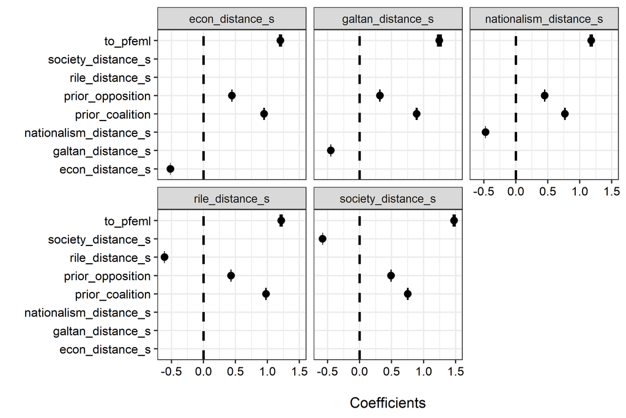

```r
### Final graph ###
ggplot(Bind_model_data, aes(x = term, y = estimate)) +
  geom_point(size = 6) +
  facet_wrap(~model) +
  coord_flip() +
  geom_hline(yintercept = 0, colour = "black", lty = 2, size = 2) +
  scale_x_discrete("") +
  scale_y_continuous("\nCoefficients") +
  geom_point(aes(x = term, y = estimate)) +
  geom_linerange(aes(x = term, ymin = conf.low_95, ymax = conf.high_95),
                 lwd = 1 / 2) +
  geom_errorbar(aes(ymin = conf.low_95, ymax = conf.high_95), size = 10,
                width = 0) +
  theme_bw(base_size = 25) +
  theme(
    plot.title = element_text(size = 22, hjust = 0.5, colour = "black"),
    axis.text = element_text(size = 21, colour = "black"),
    plot.caption = element_text(size = 21, hjust = 0, colour = "black")
  )
```

```r
ggsave("_graphs/ideological_scale.png", width = 12, height = 8)
```

# Imputing Missing Data

```r
load("_data/dyadic_data_1-4-22.Rdata")
```

First, let us check the number of rows in the data provided by the original authors.

```r
nrow(updated_data)
```

```
## [1] 2266
```

```r
dta2 <- updated_data |>
  mutate(cntryyr = paste(country, year, sep = "")) |> # creating the country-year fixed effects
  filter(to_prior_seats >= 4) |>  # Removing smaller parties
  select(year, country, rile_distance_s, prior_coalition, prior_opposition,
         econ_distance_s, society_distance_s, party_dislike, party_like, cntryyr,
         to_pfeml, to_prior_seats, to_mp_number) # selecting variables

dta <- dta2 |>
  na.omit()
```

Then the number of rows in transformed data.

```r
nrow(dta)
```

```
## [1] 1842
```

And the difference between the two, so how many rows were lost.

```r
nrow(updated_data) - nrow(dta)
```

```
## [1] 424
```

We have thus lost 424 observations. Yet, we only have 177 missing observations as part of the variables necessary for Table 1.1, as demonstrated below.

```r
updated_data |>
  select(party_like, to_pfeml, cntryyr) |>
  na.omit() |>
  nrow() - nrow(dta)
```

```
## [1] 177
```

For Table 1.2, we also have only 177 missing observations.

```r
true.missing <- updated_data |>
  select(party_like, to_pfeml, cntryyr, rile_distance_s,
         prior_coalition, prior_opposition) |>
  na.omit() |>
  nrow() - nrow(dta)
true.missing
```

```
## [1] 177
```

From the 424 originally excluded observations, we can remove the 177 true missing to see how many observations were excluded unnecessarily.

```r
nrow(updated_data) - nrow(dta) - true.missing
```

```
## [1] 247
```

Thus, the original authors excluded 247 observations unnecessarily. Yet, the row difference betweeen the two data sets is still only 56, not 247, probably because we are losing some rows (368) when removing smaller parties with `filter(to_prior_seats >= 4)` when creating dta2.

```r
nrow(dta2) - nrow(dta)
```

```
## [1] 56
```

## Tables Comparison

Let us now compare results with and without the missing data.

```r
table1.1 <-lm(party_like ~ to_pfeml + as.factor(cntryyr), data = dta)
table1.2 <-lm(party_like ~ to_pfeml + rile_distance_s + prior_coalition +
                prior_opposition + as.factor(cntryyr), data = dta)

table1.1_2 <-lm(party_like ~ to_pfeml + as.factor(cntryyr), data = dta2)
table1.2_2 <-lm(party_like ~ to_pfeml + rile_distance_s + prior_coalition +
                  prior_opposition + as.factor(cntryyr), data = dta2)
```

```r
# With clustered ses
stargazer(type = "html", table1.1, table1.2,
          add.lines = list(c("Country-Year Fixed Effects?", "Yes"), c("Country-Level Clustered SEs?", "Yes")),
          se = starprep(table1.1, table1.2,
                        clusters = dta$country),
          keep = c("to_pfeml", "rile_distance_s", "prior_coalition", "prior_opposition",
                   "econ_distance_s", "society_distance_s"),
  report = "vc*sp")
```

|  | *Dependent variable:* |  |
| --- | --- | --- |
|  | party_like |  |
|  | (1) | (2) |
| to_pfeml | 1.887*** | 1.726*** |
|  | (0.429) | (0.519) |
|  | p = 0.00002 | p = 0.001 |
| rile_distance_s |  | -0.596*** |
|  |  | (0.092) |
|  |  | p = 0.000 |
| prior_coalition |  | 0.943*** |
|  |  | (0.245) |
|  |  | p = 0.0002 |
| prior_opposition |  | 0.371*** |
|  |  | (0.108) |
|  |  | p = 0.001 |
| Country-Year Fixed Effects? | Yes |  |
| Country-Level Clustered SEs? | Yes |  |
| Observations | 1,842 | 1,842 |
| R<sup>2</sup> | 0.191 | 0.340 |
| Adjusted R<sup>2</sup> | 0.154 | 0.308 |
| Residual Std. Error | 1.403 (df = 1760) | 1.268 (df = 1757) |
| F Statistic | 5.136*** (df = 81; 1760) | 10.776*** (df = 84; 1757) |
| *Note:* | p<0.1; p<0.05; p<0.01 |  |

```r
stargazer(type = "html", table1.1_2, table1.2_2,
          add.lines = list(c("Country-Year Fixed Effects?", "Yes"),
                           c("Country-Level Clustered SEs?", "Yes")),
          se = starprep(table1.1_2, table1.2_2,
                        clusters = dta$country),
          keep = c("to_pfeml", "rile_distance_s", "prior_coalition", "prior_opposition",
                   "econ_distance_s", "society_distance_s"),
  report = "vc*sp")
```

|  | *Dependent variable:* |  |
| --- | --- | --- |
|  | party_like |  |
|  | (1) | (2) |
| to_pfeml | 1.887*** | 1.726*** |
|  | (0.429) | (0.519) |
|  | p = 0.00002 | p = 0.001 |
| rile_distance_s |  | -0.596*** |
|  |  | (0.092) |
|  |  | p = 0.000 |
| prior_coalition |  | 0.943*** |
|  |  | (0.245) |
|  |  | p = 0.0002 |
| prior_opposition |  | 0.371*** |
|  |  | (0.108) |
|  |  | p = 0.001 |
| Country-Year Fixed Effects? | Yes |  |
| Country-Level Clustered SEs? | Yes |  |
| Observations | 1,842 | 1,842 |
| R<sup>2</sup> | 0.191 | 0.340 |
| Adjusted R<sup>2</sup> | 0.154 | 0.308 |
| Residual Std. Error | 1.403 (df = 1760) | 1.268 (df = 1757) |
| F Statistic | 5.136*** (df = 81; 1760) | 10.776*** (df = 84; 1757) |
| *Note:* | p<0.1; p<0.05; p<0.01 |  |

> The conclusion thus far is that the results from the two data sets are perfectly identical, even though they differ on 56 observations (out of 1898, ~3% of the data). Thus, using `na.omit()` was unnecessary since it did not generate an error and did not change the results.

At the same time, I have noticed that the number of clusters used in the `se` argument of the stargazer function above still uses the `dta` dataset (with `na.omit`), not the one with the missing values. It is likely why the results are identical.

> `se` a list of numeric vectors that will replace the default coefficient values for each model. Behaves exactly like the argument coef.

I have tried changing it to `dta2`, but this leads to an error:

```r
"Error in commarobust(x, se_type = se_type, clusters = clusters, alpha = alpha) :
  `clusters` must be the same length as the model data"
```

It is likely that this is because `lm()` uses `na.omit()` on the data, but not on the cluster. Indeed, na.omit is the default treatment of missing values in lm:

> `na.action` a function which indicates what should happen when the data contain NAs. The default is set by the `na.action`

Setting `na.action = NULL` in the lm models leads to an error, so that is not an option. Our only choice then might be to impute the missing data. However, this at least explains why the original authors used `na.omit()`.

```r
"Error in lm.fit(x, y, offset = offset, singular.ok = singular.ok, ...) :
  NA/NaN/Inf in 'x'"
```

## Imputing Missing Data

### …

What if we impute the missing data? Here, we will impute missing data with the `missForest` package, as it is one of the best imputation methods.

### Imputation

```r
# Need logical and character variables as factors for missForest
# "Error: Can not handle categorical predictors with more than 53 categories."
new.data <- dta2 %>%
  select(-cntryyr) %>% # Too many categories (> 53)
  mutate(across(c(where(is.character), where(is.logical)), as.factor)) %>%
  as.data.frame()

# Parallel processing
registerDoParallel(cores = 4)

# Variables
set.seed(100)
data.imp <- missForest(new.data, verbose = TRUE, parallelize = "variables")
```

```
##   parallelizing over the variables of the input data matrix 'xmis'
##   missForest iteration 1 in progress...done!
##     estimated error(s): 0.000002240226 0
##     difference(s): 0.0000000000002255581 0
##     time: 2.01 seconds
##
##   missForest iteration 2 in progress...done!
##     estimated error(s): 0.000002178801 0
##     difference(s): 0.000000000000007116891 0
##     time: 1.54 seconds
##
##   missForest iteration 3 in progress...done!
##     estimated error(s): 0.00000224641 0
##     difference(s): 0.000000000000009959122 0
##     time: 1.5 seconds
```

```r
# Extract imputed dataset
dta3 <- data.imp$ximp

# Add back country-year
dta3 <- dta3 %>%
  mutate(cntryyr = dta2$cntryyr)
```

### Details

Why impute the data? van Ginkel explains,

> Regardless of the missingness mechanism, multiple imputation is always to be preferred over listwise deletion. Under MCAR it is preferred because it results in more statistical power, under MAR it is preferred because besides more power it will give unbiased results whereas listwise deletion may not, and under NMAR it is also the preferred method because it will give less biased results than listwise deletion.

van Ginkel, J. R., Linting, M., Rippe, R. C. A., & van der Voort, A. (2020). Rebutting existing misconceptions about multiple imputation as a method for handling missing data. *Journal of Personality Assessment*, *102*(3), 297-308. https://doi.org/10.1080/00223891.2018.1530680

Why `missForest`? It outperforms other imputation methods, including the popular MICE (multiple imputation by chained equations). You also don’t end up with several datasets, which makes it easier for following analyses. Finally, it can be applied to mixed data types (missings in numeric & categorical variables).

Waljee, A. K., Mukherjee, A., Singal, A. G., Zhang, Y., Warren, J., Balis, U., … & Higgins, P. D. (2013). Comparison of imputation methods for missing laboratory data in medicine. *BMJ open*, *3*(8), e002847. https://doi.org/10.1093/bioinformatics/btr597

Stekhoven, D. J., & Bühlmann, P. (2012). MissForest—non-parametric missing value imputation for mixed-type data. *Bioinformatics*, *28*(1), 112-118. https://doi.org/10.1093/bioinformatics/btr597

## Final Tables Comparison

Let us now compare results with and without the imputed data.

```r
table1.1_3 <-lm(party_like ~ to_pfeml + as.factor(cntryyr), data = dta3)
table1.2_3 <-lm(party_like ~ to_pfeml + rile_distance_s + prior_coalition +
                  prior_opposition + as.factor(cntryyr), data = dta3)

# With clustered ses
stargazer(type = "html", table1.1, table1.2,
          add.lines = list(c("Country-Year Fixed Effects?", "Yes"), c("Country-Level Clustered SEs?", "Yes")),
          se = starprep(table1.1, table1.2,
                        clusters = dta$country),
          keep = c("to_pfeml", "rile_distance_s", "prior_coalition", "prior_opposition",
                   "econ_distance_s", "society_distance_s"),
  report = "vc*sp")
```

|  | *Dependent variable:* |  |
| --- | --- | --- |
|  | party_like |  |
|  | (1) | (2) |
| to_pfeml | 1.887*** | 1.726*** |
|  | (0.429) | (0.519) |
|  | p = 0.00002 | p = 0.001 |
| rile_distance_s |  | -0.596*** |
|  |  | (0.092) |
|  |  | p = 0.000 |
| prior_coalition |  | 0.943*** |
|  |  | (0.245) |
|  |  | p = 0.0002 |
| prior_opposition |  | 0.371*** |
|  |  | (0.108) |
|  |  | p = 0.001 |
| Country-Year Fixed Effects? | Yes |  |
| Country-Level Clustered SEs? | Yes |  |
| Observations | 1,842 | 1,842 |
| R<sup>2</sup> | 0.191 | 0.340 |
| Adjusted R<sup>2</sup> | 0.154 | 0.308 |
| Residual Std. Error | 1.403 (df = 1760) | 1.268 (df = 1757) |
| F Statistic | 5.136*** (df = 81; 1760) | 10.776*** (df = 84; 1757) |
| *Note:* | p<0.1; p<0.05; p<0.01 |  |

```r
stargazer(type = "html", table1.1_3, table1.2_3,
          add.lines = list(c("Country-Year Fixed Effects?", "Yes"),
                           c("Country-Level Clustered SEs?", "Yes")),
          se = starprep(table1.1_3, table1.2_3,
                        clusters = dta3$country),
          keep = c("to_pfeml", "rile_distance_s", "prior_coalition", "prior_opposition",
                   "econ_distance_s", "society_distance_s"),
  report = "vc*sp")
```

|  | *Dependent variable:* |  |
| --- | --- | --- |
|  | party_like |  |
|  | (1) | (2) |
| to_pfeml | 1.890*** | 1.741*** |
|  | (0.443) | (0.527) |
|  | p = 0.00002 | p = 0.001 |
| rile_distance_s |  | -0.605*** |
|  |  | (0.088) |
|  |  | p = 0.000 |
| prior_coalition |  | 0.907*** |
|  |  | (0.245) |
|  |  | p = 0.0003 |
| prior_opposition |  | 0.366*** |
|  |  | (0.104) |
|  |  | p = 0.0005 |
| Country-Year Fixed Effects? | Yes |  |
| Country-Level Clustered SEs? | Yes |  |
| Observations | 1,898 | 1,898 |
| R<sup>2</sup> | 0.198 | 0.347 |
| Adjusted R<sup>2</sup> | 0.162 | 0.316 |
| Residual Std. Error | 1.403 (df = 1816) | 1.267 (df = 1813) |
| F Statistic | 5.536*** (df = 81; 1816) | 11.453*** (df = 84; 1813) |
| *Note:* | p<0.1; p<0.05; p<0.01 |  |

> After imputation, the numbers differ a little bit (good sign that they are not identical!). However, the results appear pretty robust since they are very similar and nothing has changed signed or significance threshold.